# Data from Young Professionals to explore Marketing potential

```r
    setwd("/home/champ/Documents/Grad School/BA7315/Module3")
    professionalsdata <- read.csv("Professional.csv",stringsAsFactors = FALSE)
    summary(professionalsdata)
```

```
##       Age           Gender          RealEstatePurchases ValueOfInvestments_USD
##  Min.   :19.00   Length:410         Length:410          Min.   :     0
##  1st Qu.:28.00   Class :character   Class :character    1st Qu.: 18300
##  Median :30.00   Mode  :character   Mode  :character    Median : 24800
##  Mean   :30.11                                          Mean   : 28538
##  3rd Qu.:33.00                                          3rd Qu.: 34275
##  Max.   :42.00                                          Max.   :133400
##  NumberOfTransactions BroadbandAccess    HouseholdIncome_USD HaveChildren
##  Min.   : 0.000       Length:410         Min.   : 16200      Length:410
##  1st Qu.: 4.000       Class :character   1st Qu.: 51625      Class :character
##  Median : 6.000       Mode  :character   Median : 66050      Mode  :character
##  Mean   : 5.973                          Mean   : 74460
##  3rd Qu.: 7.000                          3rd Qu.: 88775
##  Max.   :21.000                          Max.   :322500
```

# 95% Confidence Intervals for Mean Age and Household Income

```r
    mean_age <- mean(professionalsdata$Age)
    mean_household_income <- mean(professionalsdata$HouseholdIncome_USD)

    sprintf("The average age is %f", mean_age)
```

```
## [1] "The average age is 30.112195"
```

```r
    t.test(professionalsdata$Age, conf.level = 0.95)
```

```
##
##  One Sample t-test
##
## data:  professionalsdata$Age
## t = 151.52, df = 409, p-value < 2.2e-16
## alternative hypothesis: true mean is not equal to 0
## 95 percent confidence interval:
##  29.72153 30.50286
## sample estimates:
## mean of x
##   30.1122
```

```r
    sprintf("Average household income is %f", mean_household_income)
```

```
## [1] "Average household income is 74459.512195"
```

```r
    t.test(professionalsdata$HouseholdIncome_USD, conf.level = 0.95)
```

```
##
##  One Sample t-test
##
## data:  professionalsdata$HouseholdIncome_USD
## t = 43.302, df = 409, p-value < 2.2e-16
## alternative hypothesis: true mean is not equal to 0
## 95 percent confidence interval:
##  71079.26 77839.77
## sample estimates:
## mean of x
##  74459.51
```

# Proportion of subscribers who have Broadband Access

```r
    broadband_access <- table(professionalsdata$BroadbandAccess)["Yes"]
    sprintf("%g of 410 subscribers have broadband access.", broadband_access)
```

```
## [1] "256 of 410 subscribers have broadband access."
```

```r
    n <- 410
    percent_with_bba <- broadband_access/n
    sprintf("%f percent of the sample population has broadband at home.", percent_with_bba)
```

```
## [1] "0.624390 percent of the sample population has broadband at home."
```

```r
    prop.test(256,410,conf.level=0.95, correct = FALSE)
```

```
##
##  1-sample proportions test without continuity correction
##
## data:  256 out of 410, null probability 0.5
## X-squared = 25.376, df = 1, p-value = 4.718e-07
## alternative hypothesis: true p is not equal to 0.5
## 95 percent confidence interval:
##  0.5765632 0.6699080
## sample estimates:
##         p
## 0.6243902
```

# Young Professionals with Children at home

```r
    has_children <- table(professionalsdata$HaveChildren)["Yes"]
    sprintf("%g of 410 subscribers have children.", has_children)
```

```
## [1] "219 of 410 subscribers have children."
```

```r
    n <- 410
    percent_with_children <- has_children/n
    sprintf("%f percent of the sample population have children.", percent_with_children)
```

```
## [1] "0.534146 percent of the sample population have children."
```

```r
    prop.test(219,410,conf.level=0.95, correct = FALSE)
```

```
##
##  1-sample proportions test without continuity correction
##
## data:  219 out of 410, null probability 0.5
## X-squared = 1.9122, df = 1, p-value = 0.1667
## alternative hypothesis: true p is not equal to 0.5
## 95 percent confidence interval:
##  0.4857681 0.5818907
## sample estimates:
##         p
## 0.5341463
```

# D. Advertising to Young Professionals

## - A good advertising outlet for Online Brokers

[output not shown]

## - Education Software and Computer Games

[output not shown]

# A simple random sample of 385 employees from the database of 2500 employees using R functions set.seed(155)

```r
    eai_data <- read.csv("EAI.csv",stringsAsFactors = FALSE)
    set.seed(155)
    eai_subset<-eai_data[sample(1:nrow(eai_data),385),]

#   Point estimate of the mean proportion of employees in  EAI_subset data that completed the training program
    eai_completed_training <- table(eai_subset$Training.Program)["Yes"]
    sprintf("%g of 385 completed the training program", eai_completed_training)
```

```
## [1] "229 of 385 completed the training program"
```

```r
    proportion_pop <- 229/385
    sprintf("%f is the proportion of the sample population that completed the training progam", proportion_pop)
```

```
## [1] "0.594805 is the proportion of the sample population that completed the training progam"
```

# Home Prices Hypothesis

```r
    home_prices <- read.csv("home_prices_WT.csv", stringsAsFactors = FALSE)
    summary(home_prices$PRICE)
```

```
##    Min. 1st Qu.  Median    Mean 3rd Qu.    Max.
##    1350    1975    2400    2649    3000    5375
```

```r
    with(home_prices, by(PRICE, NBR, summary))
```

```
## NBR: NO
##    Min. 1st Qu.  Median    Mean 3rd Qu.    Max.
##    1350    1920    2350    2458    2625    5250
## ------------------------------------------------------------
## NBR: YES
##    Min. 1st Qu.  Median    Mean 3rd Qu.    Max.
##    1548    2016    2462    2745    3125    5375
```

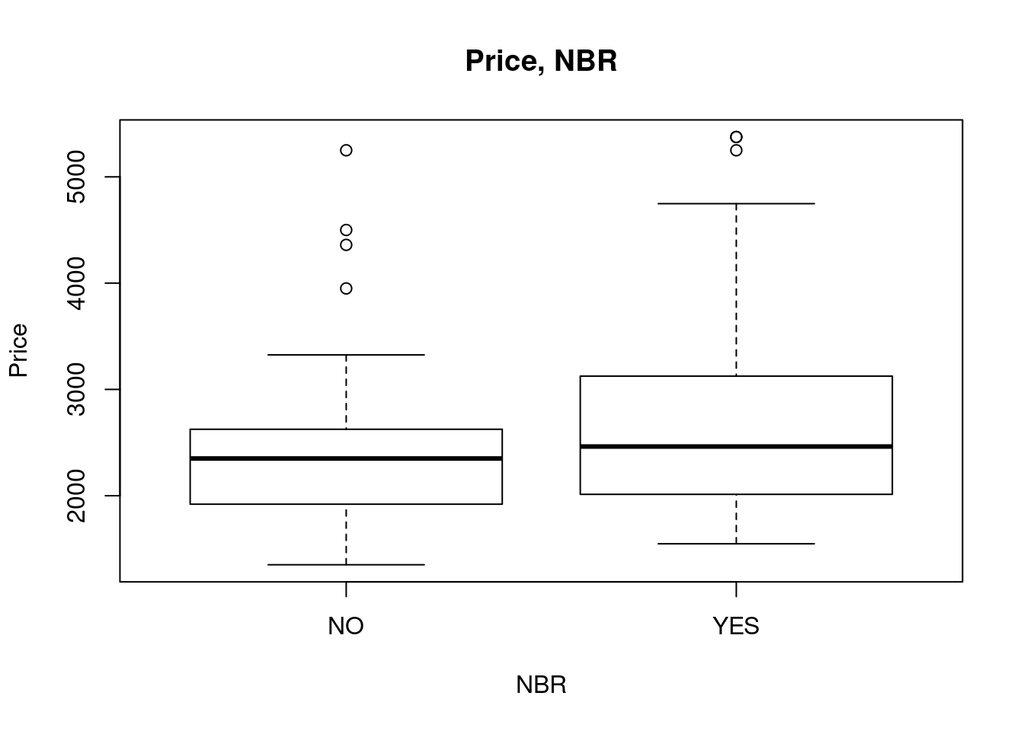

```r
    with(home_prices, boxplot(PRICE~NBR, main="Price, NBR", ylab="Price"))
```

## Prices across Corner

```r
    with(home_prices, by(PRICE, CORNER, summary))
```

```
## CORNER: NO
##    Min. 1st Qu.  Median    Mean 3rd Qu.    Max.
##    1350    1986    2388    2667    3044    5375
## ------------------------------------------------------------
## CORNER: YES
##    Min. 1st Qu.  Median    Mean 3rd Qu.    Max.
##    1748    1939    2469    2571    2829    5250
```

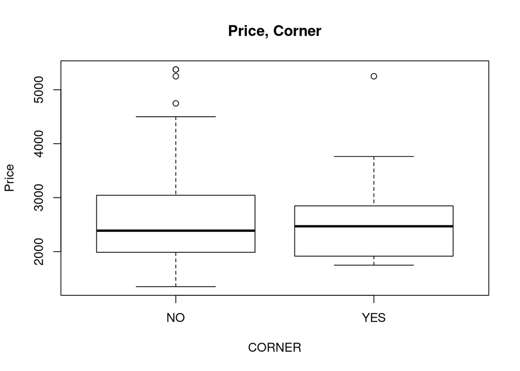

```r
    with(home_prices, boxplot(PRICE~CORNER, main="Price, Corner", ylab="Price"))
```

# T-Test for Home Resale based on Location

Step 1.

Step 2. Alpha=0.05 Step 3. The test statistic is presented below. The output shows that the t value is 1.6727.

```r
    nbr_yes<-subset(home_prices, subset=(NBR=="YES"))$PRICE #subset the data with for those located in the Northeast sector
    nbr_no<-subset(home_prices, subset=(NBR=="NO"))$PRICE #subset the data outside the Northeast sector

    #t.test

    t.test(nbr_yes, nbr_no, alternative = "two.sided", conf.level = 0.95)
```

```
##
##  Welch Two Sample t-test
##
## data:  nbr_yes and nbr_no
## t = 1.6727, df = 83.529, p-value = 0.09812
## alternative hypothesis: true difference in means is not equal to 0
## 95 percent confidence interval:
##  -54.16632 627.56375
## sample estimates:
## mean of x mean of y
##  2744.712  2458.013
```

Step 4. Using the output, the p value is determined to be 0.09812.

Step 5. Since the p-value of 0.09812 is greater than our alpha level of 0.05, we accept the null hypothesis.

## T-Test for Home Resale based on Corner Lots

Step 1.

H0: The mean resale of corner lots are equal to those of non corner lots

Ha: The mean resale of corner lots are not equal to those of non corner lots

The wordings on the alternative hypothesis indicate that this is a two sample and two-tailed hypothesis test.

Step 2. Alpha=0.05

Step 3. The test statistic is presented below. The output shows that the t value is -0.4843

```r
    corner_yes<-subset(home_prices, subset=(CORNER=="YES"))$PRICE #subset the data with for those located on Corners
    corner_no<-subset(home_prices, subset=(CORNER=="NO"))$PRICE #subset the data on non Corner real estate

    #t.test

    t.test(corner_yes, corner_no, alternative = "two.sided", conf.level = 0.95)
```

```
##
##  Welch Two Sample t-test
##
## data:  corner_yes and corner_no
## t = -0.4843, df = 34.772, p-value = 0.6312
## alternative hypothesis: true difference in means is not equal to 0
## 95 percent confidence interval:
##  -501.7991  308.5312
## sample estimates:
## mean of x mean of y
##  2570.682  2667.316
```

Step 4. Using the output, the p value is determined to be 0.6312.

Step 5. Since the p-value of 0.6312 is greater than our alpha level of 0.05, we accept the null hypothesis.

Step 6. The hypothesis test provides sufficient evidence that the mean resale of corner lots are equal to those of non corner lots.